# Simplifying a SUMO map using kmeans clustering.

Quentin Goss `quentingoss0323@floridapoly.edu`

Florida Polytechnic University `COP5090.01`

05 November 2018

# Introduction

The end goal of this project is to create an R script which will simplify a graph consisting of nodes and edges. The nodes are placed into clusters using the base K-means clustering method in R `kmeans`. A new simpler graph is created from the centers of each cluster. This document records the most important data wrangling and data combination steps involved in the automation of graph simplification. The full R project may be find at [COP5090.01-Final_Project GitHub repository](https://github.com/QuentinGoss/COP5090.01-Final_Project).

# Background

The graphs that this script simplifies are derived from road map networks (RMN) used with the vehicular traffic simulation software SUMO (**S**imulation of **U**rban **Mo**bility). The SUMO RMN data we input into the script is not raw SUMO RMN data but cleaned node and edge data stored in JSON (**J**ava**s**cript **O**bject **N**otation) format. Figure 1 is the SUMO RMN of the project `leopard` that we use to demonstrate process of the script. The project `leopard` consists of many roads, which we refer to as edges and intersections where roads connect which we refer to as junctions.

[figure not shown]

**Figure 1 -** The SUMO project `leopard`.

The data for each SUMO RMN such as `leopard` is stored in two (2) `.json` files. `junctions.json` which has intersection data, these are the vertices of the graph or nodes. Second is `edges.json` which has road data, these are the edges of the graph.

```
"gneJ10": {
         "true_center_coords": [85.58,106.58],
         "normal_center_coords": [0.8933573510362693,0.7615924550800834]
},
```

**Figure 2 -** A sample JSON object from `junctions.json`.

```
"gneJ3_to_gneJ2": {
        "true_coords": [[108.42,74.06],[73.94,55.94]],
        "normal_coords": [[0.9087664615716753,0.673459985365457],[0.885504371761658,0.6243529634949456]],
        "from": "gneJ3",
        "to": "gneJ2"
},
```

**Figure 3-** A sample JSON object from `edges.json`.

# Compiling directed graphs.

We create the directed graph with the help of the `statnet` library. The data wrangling is wordy and ommitted for brevity.

```r
library(statnet)
```

```r
adjacency.network2 <- network(adjacency.matrix, matrix.type="adjacency", directed=FALSE, cignore.eval=FALSE, names.eval="value")
# We ommited the gplot method fro brevity. This is the code to create the plot but,
# for demonstration we include a PNG with a better resolution instead.
#gplot(adjacency.network2, gmode="digraph", label=adjacency.network2%v%'vertex.names', arrowhead.cex=1)
```

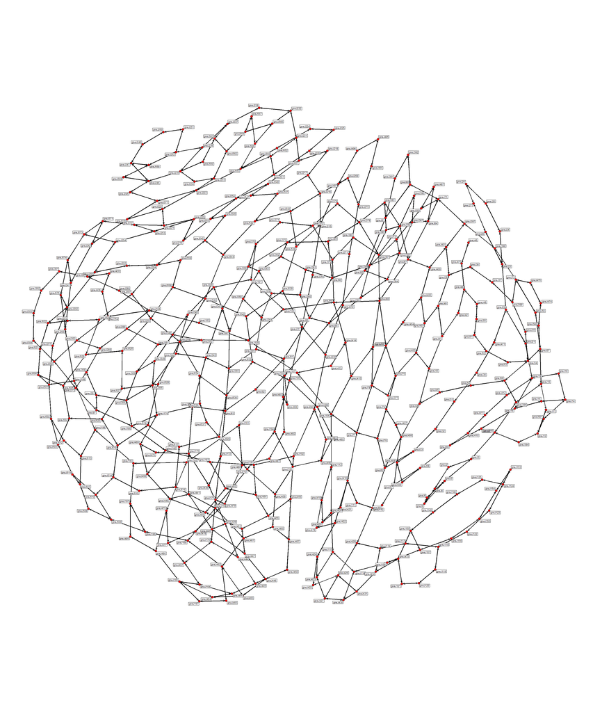

**Figure 4 -** The directed graph for project `leopard`.

# Clustering with kmeans

In the previous sections we sucessfully read in the SUMO RMN data of project `leopard` which is in JSON format. In this section we perform k-means clustering on project `leopard`.We will use the script `SUMO.project2plot.R` to retrieve the `true_center_coords` `x` and `y` coordinates and junction names from `junctions.json` in project `leopard`. We begin by importing the script `SUMO.project2plot.R`, which contains wordy data wrangling methods.

```r
source(file='../scripts/SUMO.project2plot.R')
```

Before we can perform k-means clustering on our data we must structure the data to work with the built in R function `kmeans`. To start, we retrieve the `x`, `y` and `names` of our junctions by extracting the data from the `.json` file for the project `leopard` in the `jsons` directory.

```r
# Get a junctions.matrix from the json files for project `leopard`
junctions.matrix <- project.name2jm('leopard')
# Extract the data we want from junction.data at column 'True Coords' (default)
xynames <- jm2xynames(junctions.matrix)
# Summarize our object `xynames`
print(summary(xynames))
```

```
     Length Class  Mode
[1,] 412    -none- numeric
[2,] 412    -none- numeric
[3,] 412    -none- character
```

```r
# Unlist and give x, y, and names their own vectors.
coords.x <- unlist(xynames[1])
coords.y <- unlist(xynames[2])
coords.names <- unlist(xynames[3])
# Clean up
rm(junctions.matrix,xynames)
```

Next, we combine the coordinate data into a format readable by the `kmeans` function.

```r
coords.matrix <- cbind(coords.x,coords.y)
colnames(coords.matrix) <- c('x','y')
rownames(coords.matrix) <- coords.names
print(head(coords.matrix,n=5L))
```

```
              x       y
gneJ10    85.58  106.58
gneJ100 -261.90  -11.07
gneJ101 -289.27    2.26
gneJ103 -291.37  -81.94
gneJ104 -284.35 -107.19
```

Then we use the built in `kmeans` function to find some clusters. We ommit the output of the `kmeans` function here since it is very long.

```r
ncenters <- 6
coords.clusters <- kmeans(x = coords.matrix, centers = ncenters, iter.max = 50, nstart = 27, algorithm = 'Hartigan-Wong')
```

Finally, we view the plot of our `kmeans` clustered junction data.

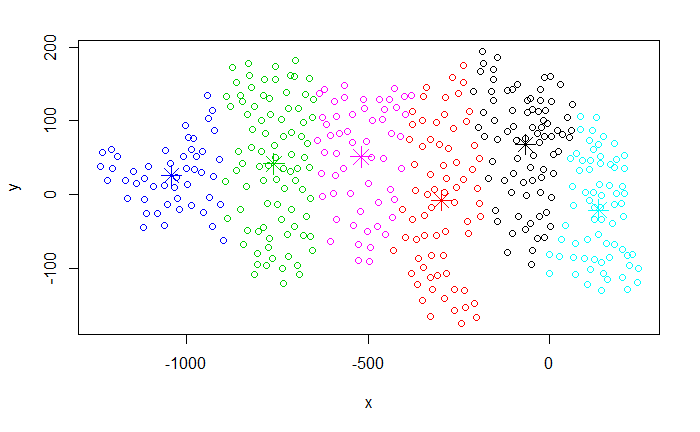

```r
plot(x = coords.matrix, col = coords.clusters$cluster)
points(coords.clusters$centers, col = 1:ncenters , pch = 8, cex = 2)
```

# Finding neighbors

In this section we will be finding connections between clustered regions. For the examples on this page we will be using the project `leopard` since the amount of points is visually fitting and sized nicely for the base R plots. We are going to need a coordinate matrix of the `leopard` project which we will get with the help of the script `clusterSUMO.project.R`.

```r
source(file='../scripts/clusterSUMO.project.R')
```

We start by performing k-means clustering on our `leopard` project. We use the `plot.kmeans` method from our script `clusterSUMO.project.R` to visualize our k-means clustered set of points and also to retrieve our cluster data which we put into the R object `coords.clusters`.

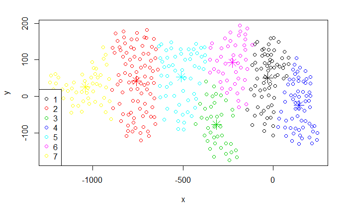

```r
coords.clusters <- plot.kmeans(project.name2cm('leopard'),k=7,return.cc=T)
```

We take a look at our `coords.clusters` dataframe.

```r
print(head(coords.clusters$cluster))
```

```
 gneJ10 gneJ100 gneJ101 gneJ103 gneJ104 gneJ106
      1       3       3       3       3       1
```

```r
print(coords.clusters$centers)
```

```
            x         y
1   -29.64588  50.33779
2  -758.84273  41.96261
3  -314.17667 -77.50359
4   143.18984 -24.56969
5  -510.66224  52.96362
6  -226.34478  92.71261
7 -1042.40837  26.24510
```

```r
print(coords.clusters$totss)
```

```
[1] 66817437
```

```r
print(coords.clusters$withinss)
```

```
[1]  529096.4 1049681.2  262734.3  432609.7  623096.3  345776.4  543155.6
```

```r
print(coords.clusters$betweenss)
```

```
[1] 63031288
```

```r
print(coords.clusters$size)
```

```
[1] 68 88 39 64 58 46 49
```

```r
print(coords.clusters$iter)
```

```
[1] 4
```

```r
print(coords.clusters$ifault)
```

```
[1] 0
```

In our `coords.clusters` data frame, we are given the location of the cluster means.

```r
print(coords.clusters$centers)
```

```
            x         y
1   -29.64588  50.33779
2  -758.84273  41.96261
3  -314.17667 -77.50359
4   143.18984 -24.56969
5  -510.66224  52.96362
6  -226.34478  92.71261
7 -1042.40837  26.24510
```

We can plot the centers now too.

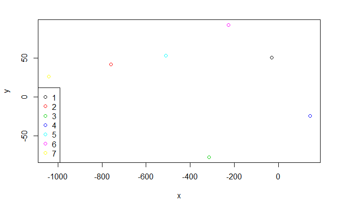

```r
k <- nrow(coords.clusters$centers)
plot(coords.clusters$centers,col=1:k)
legend('bottomleft', pch = rep(1,k), legend = 1:k, col = unique(1:k))
```

Now we want to know how each cluster connects to one another. To do this, we’ll need our junction and edge data which we can retrieve with the help of the script `sumo_dg_viewer.R` which is loaded along with `clusterSUMO.project.R`.

```r
jmem <- json2matrices('leopard')
junctions.matrix <- jmem[[1]]
edges.matrix <- jmem[[2]]
rm(jmem) # Clean up temporary object
print(head(junctions.matrix,n=5L))
```

```
        true_center_coords normal_center_coords
gneJ10  Numeric,2          Numeric,2
gneJ100 Numeric,2          Numeric,2
gneJ101 Numeric,2          Numeric,2
gneJ103 Numeric,2          Numeric,2
gneJ104 Numeric,2          Numeric,2
```

```r
print(head(edges.matrix,n=5L))
```

```
                   true_coords normal_coords from      to
gneJ3_to_gneJ2     Numeric,4   Numeric,4     "gneJ3"   "gneJ2"
gneJ99_to_gneJ88   Numeric,4   Numeric,4     "gneJ99"  "gneJ88"
gneJ100_to_gneJ99  Numeric,4   Numeric,4     "gneJ100" "gneJ99"
gneJ101_to_gneJ100 Numeric,4   Numeric,4     "gneJ101" "gneJ100"
gneJ104_to_gneJ103 Numeric,4   Numeric,4     "gneJ104" "gneJ103"
```

To view the simplified network, we initialize an empty adjacency matrix to store our connection data in.

```r
adjacency.matrix <- matrix(data = rep(0,k * k),nrow = k,ncol = k)
rownames(adjacency.matrix) <- paste0('cluster_',1:k)
colnames(adjacency.matrix) <- paste0('cluster_',1:k)
#print(adjacency.matrix) # Ommitted for brevity
```

Then we go to each of our edges one by one and note which cluster they begin in and which cluster they end in. I.e. if we have a node `node.from.1` which is in cluster 3 and `node.to.5` we’ll increment the value of the adjency matrix at `row = cluster_3` and `column = cluster_5`.

```r
for (i in 1:nrow(edges.matrix)){
  # From
  node.from <- edges.matrix[[i,'from']]
  node.from.cluster <- coords.clusters$cluster[node.from]

  # To
  node.to <- edges.matrix[[i,'to']]
  node.to.cluster <- coords.clusters$cluster[node.to]

  # Update adjacency table
  if (node.to.cluster != node.from.cluster){
    adjacency.matrix[node.from.cluster,node.to.cluster] <- adjacency.matrix[node.from.cluster,node.to.cluster] + 1
  }
}
print(adjacency.matrix)
```

```
          cluster_1 cluster_2 cluster_3 cluster_4 cluster_5 cluster_6 cluster_7
cluster_1         0         0         1        11         0         7         0
cluster_2         0         0         0         0         9         0         9
cluster_3         1         0         0         0         6         5         0
cluster_4        11         0         0         0         0         0         0
cluster_5         0         9         6         0         0         5         0
cluster_6         7         0         5         0         5         0         0
cluster_7         0         9         0         0         0         0         0
```

Now we view the directed graph.

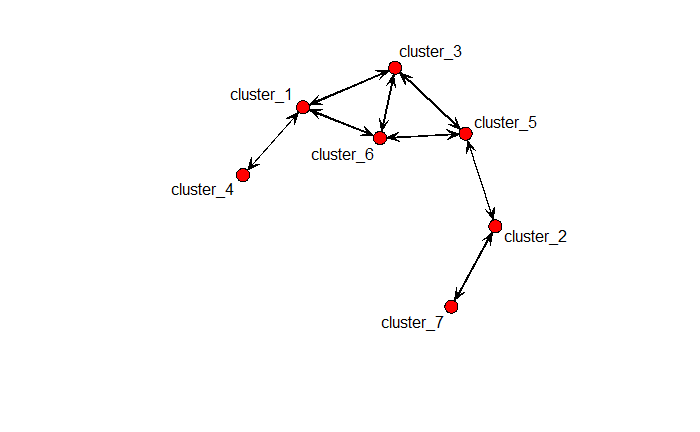

```r
adjacency.network <- network(adjacency.matrix, matrix.type="adjacency", directed=FALSE, cignore.eval=FALSE, names.eval="value")
gplot(adjacency.network, gmode="digraph", label=adjacency.network%v%'vertex.names', arrowhead.cex=1)
```

# Writing the data to JSON files

Now that we have a simplified map, we must convert the R information back into JSON format. We must have three files, one that contains node information, one that contains edge information, and one that lists which nodes are in which clusters. We will need the library `jsonlite`

```r
library('jsonlite')
```

## clusters.json

We’ll write `clusters.json`. We begin by preparing the data to be written.

```r
# Amount of clusters
nn <- length(coords.clusters$size)
# Cluster names
cl.names <- paste0(rep("cluster_", nn), 1:nn)
# Size of each cluster (The amount of junctions in each cluster)
cl.size <- coords.clusters$size
# Names of all of the nodes within each cluster.
cl.max <- max(cl.size)
cl.nodes <- matrix(data = NA_character_, nrow = nn, ncol = cl.max)
# Populate the list of nodes
counter <- rep(1L,nn)
for (i in 1:length(coords.clusters$cluster)){
  cl.index <- coords.clusters$cluster[i]
  cl.nodes[cl.index,counter[cl.index]] <- names(cl.index)
  counter[cl.index] <- counter[cl.index] + 1
}
rm(counter)
```

Then we write the file. The code is ommited for brevity. And we’ll try to read in our JSON file now to check it’s correctness.

```r
clusters.json <- fromJSON(filepath)
head(summary(clusters.json),n=3L)
```

[output not shown]

## Junctions.json

Next we create the `junctions.json` file where we will store our node data. First we get the data in the proper format.

```r
jct.names <- cl.names
print(jct.names)
```

```
[1] "cluster_1" "cluster_2" "cluster_3" "cluster_4" "cluster_5" "cluster_6" "cluster_7"
```

```r
jct.coords.true <- coords.clusters$centers
print(jct.coords.true)
```

```
            x         y
1   -29.64588  50.33779
2  -758.84273  41.96261
3  -314.17667 -77.50359
4   143.18984 -24.56969
5  -510.66224  52.96362
6  -226.34478  92.71261
7 -1042.40837  26.24510
```

```r
jct.coords.norm <- norm_coords(jct.coords.true, xmin = 0, xmax = 1, ymin = 0, ymax = 1)
print(jct.coords.norm)
```

```
          x         y
1 0.8542207 0.7510530
2 0.2391752 0.7018498
3 0.6142314 0.0000000
4 1.0000000 0.3109804
5 0.4485045 0.7664794
6 0.6883138 1.0000000
7 0.0000000 0.6095113
```

```r
# We also need to normalize the data.
```

Then we write the file. The code is ommitted for brevity. And we will test the integrity of the data by loading the newly written file.

```r
junctions.json <- fromJSON(filepath)
head(summary(junctions.json),n=3L)
```

[output not shown]

## edges.json

Lastly we create the `edges.json`. We prepare the data to be written.

```r
# Get number of unique connections between nodes
nconn <- sum(adjacency.matrix != 0)
# Names
edges.names <- rownames(adjacency.matrix)
# Initialize variables
edges.id <- rep(NA_character_,nconn)
edges.from <- rep(NA_character_,nconn)
edges.to <- rep(NA_character_,nconn)
edges.weight <- rep(NA_integer_,nconn)
# True coords
edges.coords.true.from <- matrix(data=rep(NA_integer_,2*nconn),nrow=nconn,ncol=2)
colnames(edges.coords.true.from) <- c('x','y')
edges.coords.true.to <- matrix(data=rep(NA_integer_,2*nconn),nrow=nconn,ncol=2)
colnames(edges.coords.true.to) <- c('x','y')
# Normal coords
edges.coords.norm.from <- matrix(data=rep(NA_integer_,2*nconn),nrow=nconn,ncol=2)
colnames(edges.coords.norm.from) <- c('x','y')
edges.coords.norm.to <- matrix(data=rep(NA_integer_,2*nconn),nrow=nconn,ncol=2)
colnames(edges.coords.norm.to) <- c('x','y')
# Populate our varaibles
counter <- 1
for (index.from in 1:nrow(adjacency.matrix)){
  for (index.to in 1:ncol(adjacency.matrix)){
    if (adjacency.matrix[index.from,index.to] != 0){
      # From
      edges.from[counter] <- edges.names[index.from]

      # to
      edges.to[counter] <- edges.names[index.to]

      # id
      edges.id[counter] <- paste0(edges.from[counter],'_to_',edges.to[counter])

      # Weight
      edges.weight[counter] <- as.integer(adjacency.matrix[index.from,index.to])

      # True Coordinates
      edges.coords.true.from[counter,'x'] <- coords.clusters$centers[index.from,'x']
      edges.coords.true.from[counter,'y'] <- coords.clusters$centers[index.from,'y']
      edges.coords.true.to[counter,'x'] <- coords.clusters$centers[index.to,'x']
      edges.coords.true.to[counter,'y'] <- coords.clusters$centers[index.to,'y']

      # Normal Coordinates
      edges.coords.norm.from[counter,'x'] <- jct.coords.norm[index.from,'x']
      edges.coords.norm.from[counter,'y'] <- jct.coords.norm[index.from,'y']
      edges.coords.norm.to[counter,'x'] <- jct.coords.norm[index.to,'x']
      edges.coords.norm.to[counter,'y'] <- jct.coords.norm[index.to,'y']

      # Increment counter
      counter <- counter + 1
    }
  }
}
```

Then we can create our `edges.json` file. The code is ommited for brevity. We verify the integrity of the file by importing it.

```r
edges.json <- fromJSON(filepath)
head(summary(edges.json),n=3L)
```

[output not shown]

# Final Script

At last, we consolidate all of our work into a single script which performs the entire simplification process from start to finish.

```r
source(file='../scripts/SUMO.kmeans.simplify.R')
```

```r
SUMO.kmeans.simplify(
  project.name = 'leopard',
  jsons.dir = '../jsons/',
  output.dir = './output/',
  plot.width = 640,
  plot.height = 480,
  plot.legend.pos = 'bottomleft',
  kmeans.k = 15,
  kmeans.iter.max = 10,
  kmeans.nstart = 1
)
```